# Data Visualization

### Scales

Scales control the mapping between data and aesthetics.

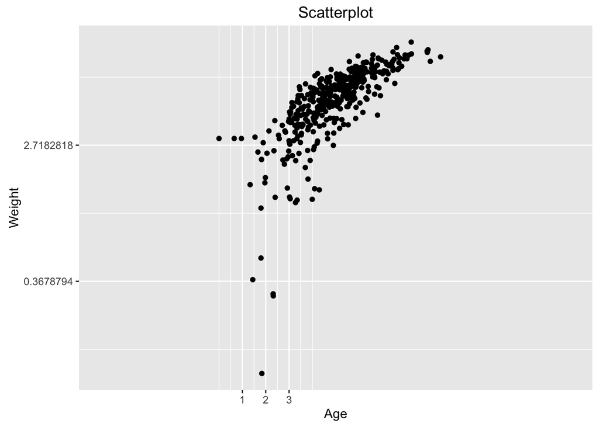

```r
ggplot(cats) +
    geom_point(aes(x = age, y = weight)) +
    scale_x_continuous(name = "Age",
                       breaks = c(1, 2, 3),
                       limits = c(-5, 15)) +
    scale_y_continuous("Weight", trans = "log") +
    ggtitle(label = "Scatterplot")
```

### Themes

The ggplot2 theme system handles non-data plot elements such as:

- Axis labels
- Plot background
- Facet label backround
- Legend appearance

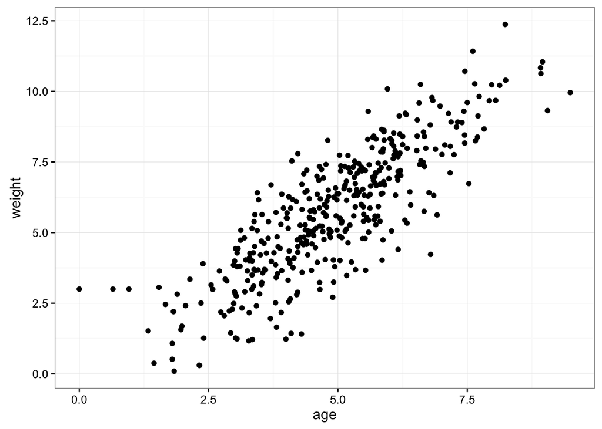

```r
ggplot(cats) +
    geom_point(aes(x = age, y = weight)) +
    theme_bw()
```

### Facets

Facets display subsets of the dataset in different panels. Let’s use the `facet_grid` function to lay out panels in a grid. Each panel will have the same geometric objects.

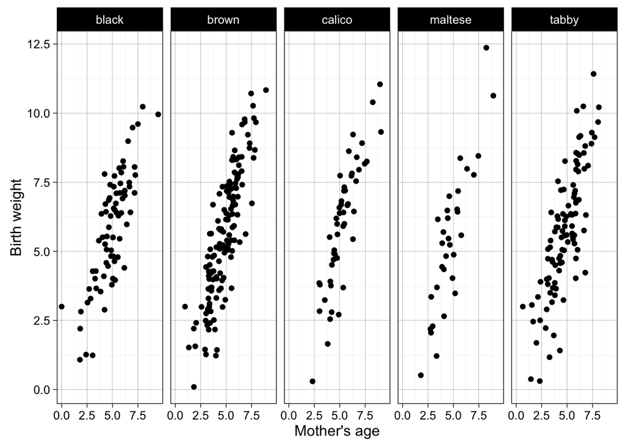

```r
ggplot(cats) +
    geom_point(aes(x = age, y = weight)) +
    xlab("Mother's age") +
    ylab("Birth weight") +
    facet_grid(. ~ coat) +
    theme_linedraw()
```

### Writing figures to file

There are two ways in which figures and plots can be output to a file (rather than simply displaying on screen).

The first (and easiest) is to export directly from the RStudio ‘Plots’ panel, by clicking on Export when the image is plotted. This will give you the option of png or pdf and selecting the directory to which you wish to save it to.

The second option is to use R functions in the console, allowing you the flexibility to specify parameters to dictate the size and resolution of the output image. Some of the more popular formats include `pdf()`, `png`, and `svg`.

Initialize a plot that will be written directly to a file using `pdf`, `png` etc. Within the function you will need to specify a name for your image, and the with and height (optional). Then create a plot using the usual functions in R. Finally, close the file using the `dev.off()` function. There are also `bmp`, `tiff`, and `jpeg` functions, though the `jpeg` function has proven less stable than the others.

```r
pdf("figure/boxplot.pdf")

ggplot(example_data) +
  geom_boxplot(aes(x = cit, y =....) +
  ggtitle(...) +
  xlab(...) +
  ylab(...) +
  theme(panel.grid.major = element_line(...),
          axis.text.x = element_text(...),
          axis.title = element_text(...),
          axis.text = element_text(...)

dev.off()
```

## Resources

We have only scratched the surface here. There are many plotting features we haven’t covered.

plotting in Base R:

- John Maindonald’s [Using R for Data Analysis and Graphics PDF](https://cran.r-project.org/doc/contrib/usingR.pdf)

ggplot2:

- [ggplot reference site](http://docs.ggplot2.org/)
- Winston Chang’s excellent [Cookbook for R](http://www.cookbook-r.com)
- [ggplot2: Elegant Graphics for Data Anaysis](http://www.amazon.com/ggplot2-Elegant-Graphics-Data-Analysis/dp/0387981403)

Much of the material here was adpapted from [Introduction to R graphics with ggplot2 Tutorial at IQSS](http://tutorials.iq.harvard.edu/R/Rgraphics/Rgraphics.html).